# Part I - Proper Loan

## Preliminary Wrangling

```python
# import all packages and set plots to be embedded inline
import numpy as np
import pandas as pd
import matplotlib.pyplot as plt
import seaborn as sb

%matplotlib inline
```

```python
loan = pd.read_csv('prosperLoanData.csv')
```

```python
loan.shape
```

```
(113937, 81)
```

```python
loan.sample(5)
```

|  | ListingKey | ListingNumber | ListingCreationDate | CreditGrade | Term | LoanStatus | ClosedDate | BorrowerAPR | BorrowerRate | LenderYield | ... | LP_ServiceFees | LP_CollectionFees | LP_GrossPrincipalLoss | LP_NetPrincipalLoss | LP_NonPrincipalRecoverypayments | PercentFunded | Recommendations | InvestmentFromFriendsCount | InvestmentFromFriendsAmount | Investors |
| --- | --- | --- | --- | --- | --- | --- | --- | --- | --- | --- | --- | --- | --- | --- | --- | --- | --- | --- | --- | --- | --- |
| 60066 | CA7E3547532800682B96CEE | 593447 | 2012-05-28 10:57:10.347000000 | NaN | 60 | Current | NaN | 0.27462 | 0.2489 | 0.2389 | ... | -94.67 | 0.0 | 0.0 | 0.0 | 0.0 | 1.0 | 0 | 0 | 0.0 | 11 |
| 16683 | 37A2356755019514958BFF8 | 698820 | 2013-01-13 09:22:07.850000000 | NaN | 36 | Current | NaN | 0.28032 | 0.2419 | 0.2319 | ... | -28.48 | 0.0 | 0.0 | 0.0 | 0.0 | 1.0 | 0 | 0 | 0.0 | 68 |
| 50248 | F3C43472839789440DB3045 | 441696 | 2010-01-08 12:11:39.310000000 | NaN | 36 | Completed | 2012-10-30 00:00:00 | 0.12480 | 0.0894 | 0.0794 | ... | -15.98 | 0.0 | 0.0 | 0.0 | 0.0 | 1.0 | 0 | 0 | 0.0 | 66 |
| 33635 | C7A635808376437630D6709 | 804240 | 2013-06-10 15:39:23.047000000 | NaN | 36 | Current | NaN | 0.26528 | 0.2272 | 0.2172 | ... | -62.28 | 0.0 | 0.0 | 0.0 | 0.0 | 1.0 | 0 | 0 | 0.0 | 1 |
| 1919 | 29B434202610164516132CC | 333584 | 2008-05-15 19:24:26.900000000 | D | 36 | Completed | 2011-05-27 00:00:00 | 0.14030 | 0.1190 | 0.1090 | ... | -22.87 | 0.0 | 0.0 | 0.0 | 0.0 | 1.0 | 0 | 0 | 0.0 | 44 |

5 rows × 81 columns

```python
loan.sort_index(axis=1,inplace=True)
```

```python
loan[loan.isnull]
```

[output not shown]

```python
loan.info()
```

```
<class 'pandas.core.frame.DataFrame'>
RangeIndex: 113937 entries, 0 to 113936
Data columns (total 81 columns):
 #   Column                               Non-Null Count   Dtype
---  ------                               --------------   -----
 0   AmountDelinquent                     106315 non-null  float64
 1   AvailableBankcardCredit              106393 non-null  float64
 2   BankcardUtilization                  106333 non-null  float64
 3   BorrowerAPR                          113912 non-null  float64
 4   BorrowerRate                         113937 non-null  float64
 5   BorrowerState                        108422 non-null  object
 6   ClosedDate                           55089 non-null   object
 7   CreditGrade                          28953 non-null   object
 8   CreditScoreRangeLower                113346 non-null  float64
 9   CreditScoreRangeUpper                113346 non-null  float64
```

[output cut: 73 more lines]

### What is the structure of your dataset?

My dataset has 113937 rows and 81 columns

### What is/are the main feature(s) of interest in your dataset?

BorrowerRate CreditGrade CurrentCreditLines DebtToIncomeRatio IncomeRange IsBorrowerHomeowner ListingCategory LoanOriginalAmount LoanStatus Occupation Recommendations Term

## Univariate Exploration

> In this section, investigate distributions of individual variables. If you see unusual points or outliers, take a deeper look to clean things up and prepare yourself to look at relationships between variables.

> **Rubric Tip**: The project (Parts I alone) should have at least 15 visualizations distributed over univariate, bivariate, and multivariate plots to explore many relationships in the data set. Use reasoning to justify the flow of the exploration.

> **Rubric Tip**: Use the "Question-Visualization-Observations" framework throughout the exploration. This framework involves **asking a question from the data, creating a visualization to find answers, and then recording observations after each visualisation.**

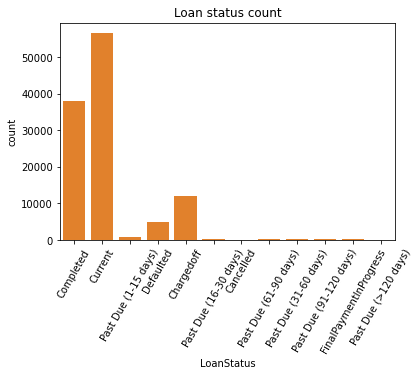

```python
color =sb.color_palette()[1]
sb.countplot(data=loan,x='LoanStatus',color=color)
plt.title('Loan status count')
plt.xticks(rotation=60);
```

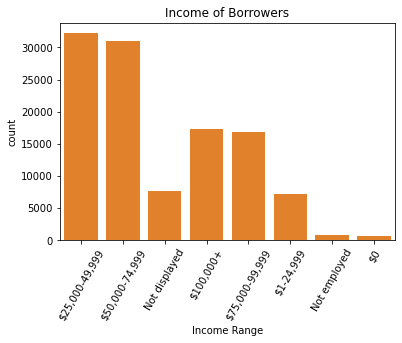

```python
sb.countplot(x=loan['IncomeRange'],color=color)
plt.xlabel('Income Range')
plt.xticks(rotation=60)
plt.title('Income of Borrowers');
```

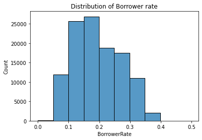

```python
sb.histplot(x=loan['BorrowerRate'],bins=10)
plt.title('Distribution of Borrower rate');
```

#### The distribution of the LoanOriginalAMount

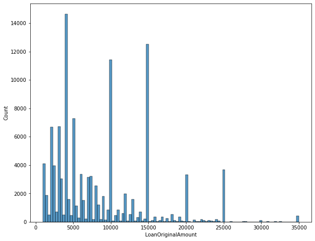

```python
plt.figure(figsize=[10,8])
sb.histplot(x=loan.LoanOriginalAmount)
```

##### What people are doing with loans

```python
loan.rename({'ListingCategory (numeric)':'ListingCategory'},axis=1,inplace=True)
```

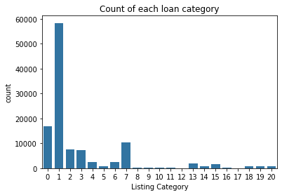

```python
color = sb.color_palette()[0]
sb.countplot(data=loan,x='ListingCategory',color=color)
plt.title('Count of each loan category')
plt.xlabel('Listing Category');
```

> **Rubric Tip**: Visualizations should depict the data appropriately so that the plots are easily interpretable. You should choose an appropriate plot type, data encodings, and formatting as needed. The formatting may include setting/adding the title, labels, legend, and comments. Also, do not overplot or incorrectly plot ordinal data.

### Discuss the distribution(s) of your variable(s) of interest. Were there any unusual points? Did you need to perform any transformations?

> What people are doing with loans From the list category above, it was deduced that most borrowers are borrowing to service previous loans.

### Of the features you investigated, were there any unusual distributions? Did you perform any operations on the data to tidy, adjust, or change the form of the data? If so, why did you do this?

> Your answer here! I did not perform any tidy,most of the nan values occur at columns that are not of interest

## Bivariate Exploration

> In this section, investigate relationships between pairs of variables in your data. Make sure the variables that you cover here have been introduced in some fashion in the previous section (univariate exploration).

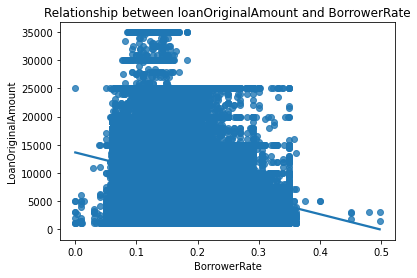

```python
sb.regplot(data=loan, y='LoanOriginalAmount',x='BorrowerRate')
plt.title('Relationship between loanOriginalAmount and BorrowerRate')
```

##### Relationship between BorrowerAPR and BorrowerRate

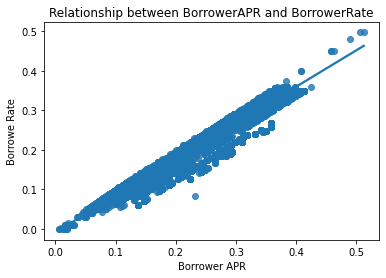

```python
sb.regplot(data=loan,x='BorrowerAPR',y='BorrowerRate')
plt.title('Relationship between BorrowerAPR and BorrowerRate')
plt.xlabel('Borrower APR')
plt.ylabel('Borrowe Rate');
```

#### Relationship between BorrowerRate and LoanStatus

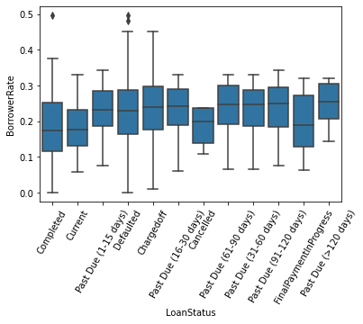

```python
color = sb.color_palette()[0]
sb.boxplot(data=loan,x='LoanStatus',y='BorrowerRate',color=color)
plt.xticks(rotation=60);
```

##### Relationship between Loan Amount and Term(Duration of Payment in Months

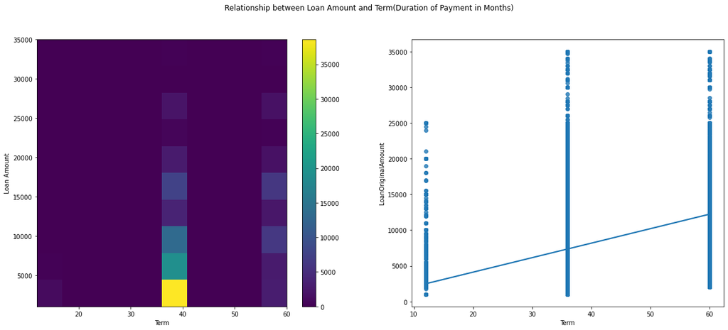

```python
fig = plt.figure(figsize=[20,8],)
plt.suptitle('Relationship between Loan Amount and Term(Duration of Payment in Months)')

plt.subplot(1,2,1)
plt.ylabel('Loan Amount')
plt.xlabel('Term')
plt.hist2d(data=loan,x='Term',y='LoanOriginalAmount')

plt.ylabel('Loan Amount')
plt.xlabel('Term')
plt.colorbar()

plt.subplot(1,2,2)
plt.ylabel('Loan Amount')
plt.xlabel('Term')
sb.regplot(data=loan, x='Term',y='LoanOriginalAmount');
```

##### Home ownership of each employment categories

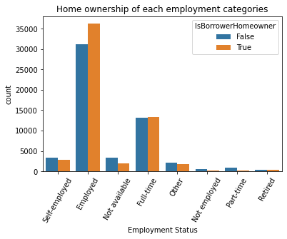

```python
sb.countplot(data=loan,x='EmploymentStatus',hue='IsBorrowerHomeowner')
plt.title('Home ownership of each employment categories')
plt.xlabel('Employment Status')
plt.xticks(rotation=60);
```

##### Relationship between LoanStatus and ListingCategory

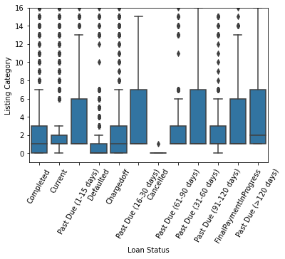

```python
color=sb.color_palette()[0]
sb.boxplot(data=loan,x='LoanStatus',y='ListingCategory', color=color);
plt.xticks(rotation = 60)
plt.xlabel('Loan Status')
plt.ylabel('Listing Category')
plt.ylim(-1,16);
```

##### Relationship between EmploymentStatus and MonthlyPayment

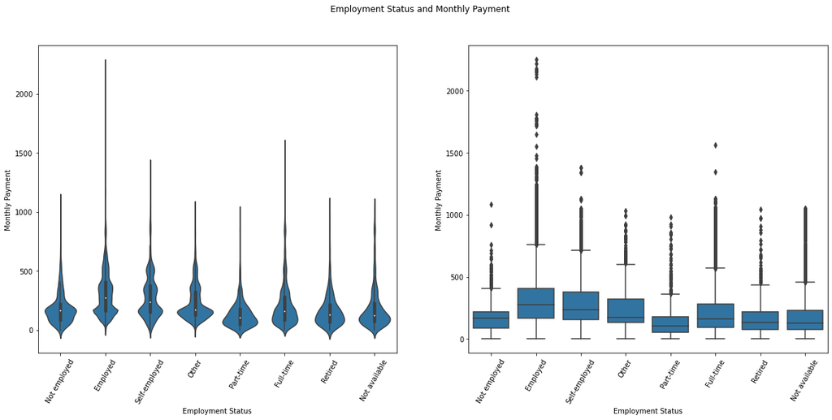

```python
employment_statuses = ['Not employed','Employed','Self-employed','Other','Part-time','Full-time','Retired','Not available']
statuses = pd.api.types.CategoricalDtype(ordered=True,categories=employment_statuses)
loan['EmploymentStatus'] =loan['EmploymentStatus'].astype(statuses)

fig = plt.figure(figsize=[20,8])
plt.subplot(121)
plt.suptitle('Employment Status and Monthly Payment')
sb.violinplot(data=loan,x='EmploymentStatus',y='MonthlyLoanPayment',color=color)
plt.xlabel('Employment Status')
plt.ylabel('Monthly Payment')
plt.xticks(rotation=60)

plt.subplot(122)
sb.boxplot(data=loan,x='EmploymentStatus',y='MonthlyLoanPayment',color=color)
plt.xlabel('Employment Status')
plt.ylabel('Monthly Payment')
plt.xticks(rotation=60);
```

##### Employment Status and Loan Status

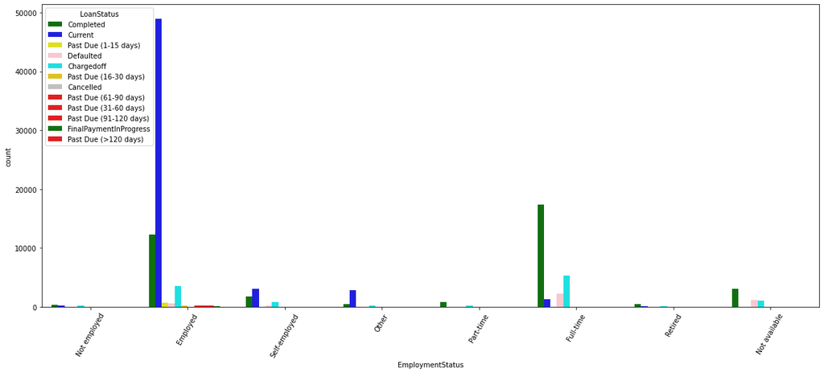

```python
color=['green','blue','yellow','pink','cyan','gold','silver','red','red','red','green','red']
fig = plt.figure(figsize=[20,8])
sb.countplot(x=loan['EmploymentStatus'],hue=loan['LoanStatus'],dodge=True,palette=color)
plt.xticks(rotation=60);
```

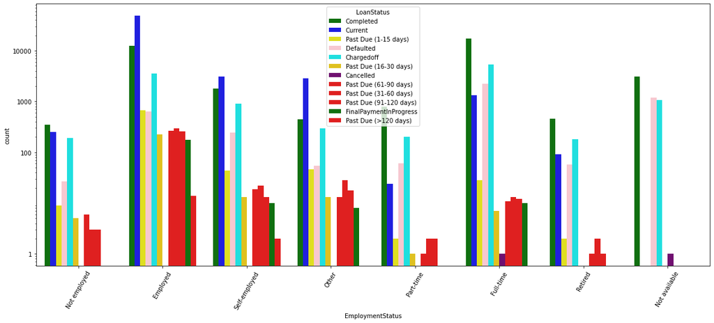

```python
color=['green','blue','yellow','pink','cyan','gold','purple','red','red','red','green','red']
fig = plt.figure(figsize=[20,8])
sb.countplot(x=loan['EmploymentStatus'],hue=loan['LoanStatus'],dodge=True,palette=color)
plt.yscale('log')
plt.yticks([1,100,1000,10000],['1','100','1000','10000'])
plt.xticks(rotation=60);
```

###### Relationship between EmploymentStatus and LoanStatus

```python
ct = loan.groupby(['EmploymentStatus','LoanStatus']).size()
```

```python
ct = ct.reset_index(name='count')
```

```python
ct = ct.pivot(index='EmploymentStatus',columns='LoanStatus',values='count')
```

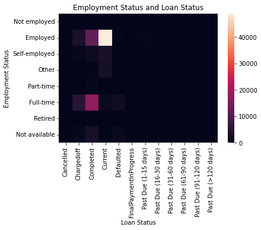

```python
sb.heatmap(ct)
plt.title('Employment Status and Loan Status')
plt.xlabel('Loan Status')
plt.ylabel('Employment Status');
```

#### Relationship between Occupation and Loan Status

```python
loan.Occupation.value_counts()
```

```
Other                          28617
Professional                   13628
Computer Programmer             4478
Executive                       4311
Teacher                         3759
                               ...
Dentist                           68
Student - College Freshman        41
Student - Community College       28
Judge                             22
Student - Technical School        16
Name: Occupation, Length: 67, dtype: int64
```

```python
loan.Occupation.nunique()
```

```
67
```

```python
loan.Occupation = loan.Occupation.fillna('Not_Available')  #replace na with Not_Available
```

```python
loan_st_count = loan.groupby(['Occupation','LoanStatus']).size()   #groupby occupation and loanstatus
```

```python
loan_st_count = loan_st_count.reset_index(name='count')
```

```python
loan_st_count = loan_st_count.pivot(index='Occupation',columns='LoanStatus',values='count')
```

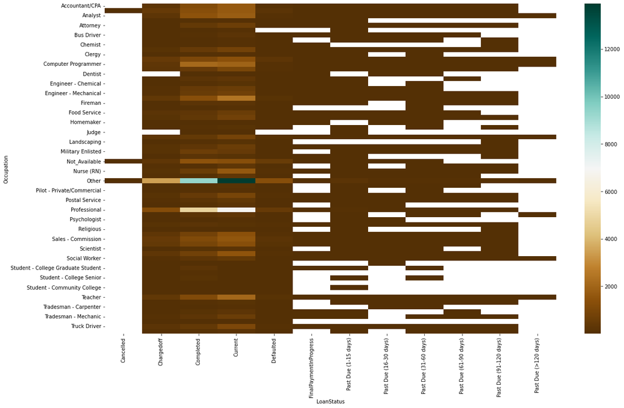

```python
fig = plt.figure(figsize=[20,12])
sb.heatmap(loan_st_count,cmap='BrBG');
```

##### Loan Status and Debt to Income Ratio

```python
corr = loan.corr()
```

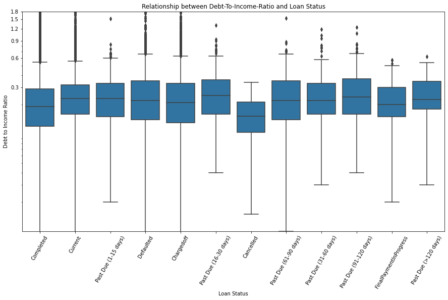

```python
fig = plt.figure(figsize=[15,8])

sb.boxplot(data=loan,x='LoanStatus',y='DebtToIncomeRatio',color=color)
plt.xticks(rotation=60);
plt.yscale('log')

ticks = [0,0.3,0.6,0.9,1.2,1.5,1.8,2.1,2.4]
labels = ['{}'.format(v) for v in ticks]

plt.title('Relationship between Debt-To-Income-Ratio and Loan Status')
plt.xlabel('Loan Status')
plt.yticks(ticks,labels)
plt.ylim(0,1.8)
plt.ylabel('Debt to Income Ratio')
```

#### Relationship between MonthlyPayment and Term

[figure not shown]

```python
sb.regplot(data=loan,x='Term', y='MonthlyLoanPayment')
plt.xlabel('Term (months)')
plt.ylabel('Monthly Payment ($)')
```

### Talk about some of the relationships you observed in this part of the investigation. How did the feature(s) of interest vary with other features in the dataset?

### Relationship between BorrowerRate and BorrowerAPR

This relationship was plotted using a scattered plot. It can be seen that the two variables have a positive correlation between them, as BorrowerRate increases, the BorrowerAPR also increases

### Relationship between LoanAMount and Term

The relationship was plotted on a scattered plot and it was obvious that the larger the loan amount, the higher the term of payment.

### Home ownership of each employment categories

I plotted this relationship using a clustered bar chart. It can be deduced that majority of borrrowe who owned a house were employees compared to much less number of self employed borrower. Also, more full-time borrowers owned a home compare to the part-time counter-parts.

### Relationship between MonthlyPayment and EmploymentStatus

The rlationship was plotted using the boxplot. It was oserved that employed borrower had the highest monthly payments and the monthly payments range from low to very high instead of concentrating in the lower range for unemployed borrowers

### Did you observe any interesting relationships between the other features (not the main feature(s) of interest)?

The relationship between MonthlyPayment and Term is a little interesting. I expect the monthly payment to be inversely related to the Term but my plot is indicating a slightly positive correlation between both variables. Perphaps, borrowers who choose a higher monthly payment end up defaulting for a long period of time.

## Multivariate Exploration

#### Relationship between AmountDelinquent,LoanStatus and IncomeRange

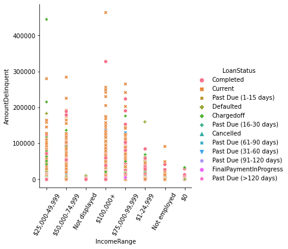

```python
fig =plt.figure(figsize=(12,18))

sb.relplot(data=loan,x='IncomeRange',y='AmountDelinquent',style='LoanStatus',hue='LoanStatus');
plt.xticks(rotation=60);
```

#### Relationship between CreditGrade,LoanStatus and DebtToIncomeRatio

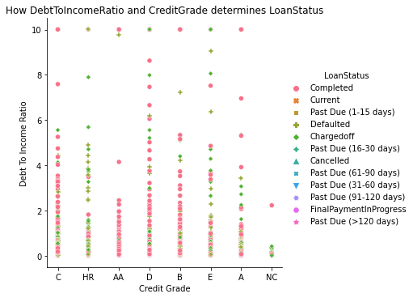

```python
fig = plt.figure(figsize=[12,12])
sb.relplot(data=loan,x='CreditGrade',y='DebtToIncomeRatio',style='LoanStatus',hue='LoanStatus');
plt.title('How DebtToIncomeRatio and CreditGrade determines LoanStatus')
plt.ylabel('Debt To Income Ratio')
plt.xlabel('Credit Grade');
```

#### Relationship between CurrentCreditLines,LoanStatus and DebtToIncomeRatio

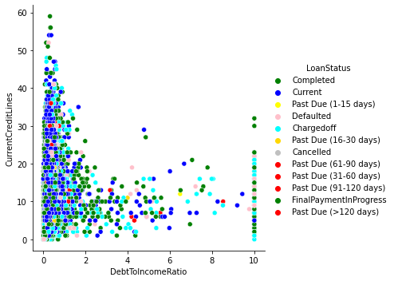

```python
color=['green','blue','yellow','pink','cyan','gold','silver','red','red','red','green','red']
fig = plt.figure(figsize=[12,10])
sb.relplot(data=loan,x='DebtToIncomeRatio',y='CurrentCreditLines',hue='LoanStatus',palette=color);
```

#### Relationship between BorrowerRate, LoanOriginalAmount and LoanStatus

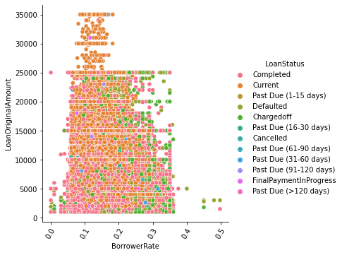

```python
sb.relplot(data=loan,x='BorrowerRate',y='LoanOriginalAmount',hue='LoanStatus')
plt.xticks(rotation=60);
```

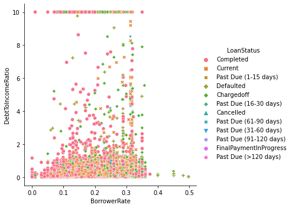

```python
sb.relplot(data=loan,x='BorrowerRate',y='DebtToIncomeRatio',hue='LoanStatus',style='LoanStatus')
```

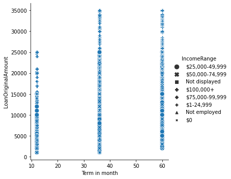

```python
sb.relplot(data=loan,x='Term',y='LoanOriginalAmount',style='IncomeRange',size='IncomeRange');
plt.xlabel('Term in month')
```

#### Relationship between LoanStatus,MonthlyPayment and EmploymentStatus

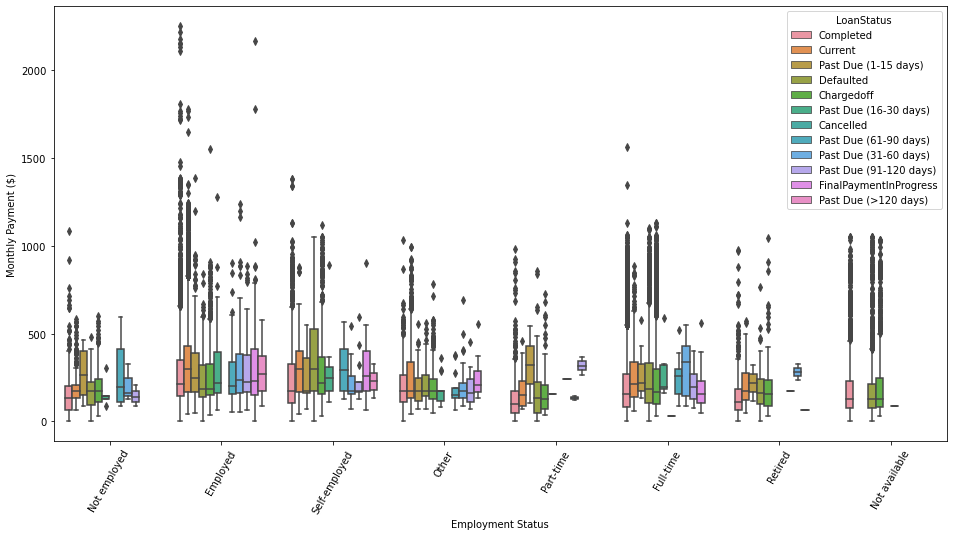

```python
fig = plt.figure(figsize=[16,8])
sb.boxplot(data=loan,x='EmploymentStatus',y='MonthlyLoanPayment',hue='LoanStatus')
plt.xlabel('Employment Status')
plt.ylabel('Monthly Payment ($)')
plt.xticks(rotation=60);
```

### Relationship between LoanOriginalAmount, IncomeRange and Term

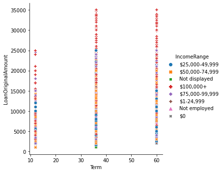

```python
sb.relplot(data=loan, x='Term',y='LoanOriginalAmount', style= 'IncomeRange', hue='IncomeRange')
# plt.xticks(rotation='')
```

### Talk about some of the relationships you observed in this part of the investigation. Were there features that strengthened each other in terms of looking at your feature(s) of interest?

Relationship between BorrowerRate, DebtToIncomeRatio and LoanStatus

I observed that most borrowers who have a borrower rate aroound 0.2 and a debt to income ration around 2 either completed their loan, in the final payment or currently servicing it. Most defaulters have a borrower rate close to 0.3 or debt to income ratio close to 3.

Relationship between CurrentCreditLines,LoanStatus and DebtToIncomeRatio Most of borrowers who have completed their payment or currently servicing the loan have credit line below 20, which is quite similar to those whose loan have been charged off.Both of these groups also have relatively low debt to income ratio.

## Conclusions

At this stage, I have noticed that the LoanStatus, which I have identified as an indication of ability of the borrower to pay back the loan depends on a number of other variables: BorrowerRate DebtToIncomeRatio CreditGrade

Suprisingly The LoanOriginalAmount and Term appear not to affect LoanStatus.